# Writing Functions in R

William Surles

2017-07-17

# Introduction

Course notes for [Writing Functions in R](https://www.datacamp.com/courses/writing-functions-in-r)

## Whats Covered

- A quick refresher
- When and how you should write a function
- Functional programming
- Advanced inputs and outputs
- Robust functions

## Additional Resources

- [Nonstandard Evaluation Vignette](http://rpubs.com/hadley/157957)
- [purr vignette](http://purrr.tidyverse.org/)

# A quick refresher

## Writing a function in R

- The parts of a function
  - Argument
  - Body
  - Environment
- Return value is the last evaluated expression or the first evaluated `return()` expression
- Functions can be treated like usual R objects

## Writing a function

```r
# Define ratio() function
ratio <- function(x, y) {
  x / y
}

# Call ratio() with arguments 3 and 4
ratio(3,4)
```

```
## [1] 0.75
```

## Arguments

```r
# Rewrite the call to follow best practices
mean(c(1:9, NA), trim = 0.1, na.rm = TRUE)
```

```
## [1] 5
```

## Function output

```r
f <- function(x) {
  if (TRUE) {
    return(x + 1)
  }
  x
}

f(2)
```

```
## [1] 3
```

## Environments

- When you call a function, a new environment is made for the function to do its work
- The new environment is populated with the argument values
- Objects are looked for first in this environment
- If they are not found they are looked for in the environmnet that the function was created in

## Testing your understanding of scoping (1)

```r
y <- 10
f <- function(x) {
  x + y
}
f(10)
```

```
## [1] 20
```

## Testing your understanding of scoping (2)

```r
y <- 10
f <- function(x) {
  y <- 5
  x + y
}
f(10)
```

```
## [1] 15
```

## Testing your understanding of scoping (3)

```r
f <- function(x) {
  y <- 5
  x + y
}
f(5)
```

```
## [1] 10
```

## Data structures

- Two types of vectors
  - Atomic vectors of six types: logical, integer, double, character, complex, raw
  - Lists (recursive vectors), because lists can contain other lists
- Vectors have two key properties
  - type and length
- Missing values
  - `NULL` often used to indicate the absence of a vector
  - `NA` used to indicate the absence of a value in a vector, aka a missing value
  - Missing values are contaigous. i.e. calling `sum` on a vector with NA will result in NA.
- Lists
  - Useful because they con contain heterogeneous objects
  - Complicated return objects are often lists, i.e. from lm()
  - Created with list()
  - Subset with `[`, `[[`, or `$`
  - `[` extracts a sublist
  - `[[` and `$` extract elements, remove a level of hierarchy

## Subsetting lists

```r
# 2nd element in tricky_list
typeof(tricky_list[[2]])
```

```
## [1] "logical"
```

```r
# Element called x in tricky_list
typeof(tricky_list[['x']])
```

```
## [1] "list"
```

```r
# 2nd element inside the element called x in tricky_list
typeof(tricky_list[['x']][[2]])
```

```
## [1] "character"
```

## Exploring lists

```r
# Guess where the regression model is stored
names(tricky_list)
```

```
## [1] "nums"  "y"     "x"     "model"
```

```r
# Use names() and str() on the model element
names(tricky_list$model)
```

```
##  [1] "coefficients"  "residuals"     "effects"       "rank"
##  [5] "fitted.values" "assign"        "qr"            "df.residual"
##  [9] "xlevels"       "call"          "terms"         "model"
```

```r
str(tricky_list$model)
```

```
## List of 12
##  $ coefficients : Named num [1:2] 37.29 -5.34
##   ..- attr(*, "names")= chr [1:2] "(Intercept)" "wt"
##  $ residuals    : Named num [1:32] -2.28 -0.92 -2.09 1.3 -0.2 ...
##   ..- attr(*, "names")= chr [1:32] "Mazda RX4" "Mazda RX4 Wag" "Datsun 710" "Hornet 4 Drive" ...
##  $ effects      : Named num [1:32] -113.65 -29.116 -1.661 1.631 0.111 ...
##   ..- attr(*, "names")= chr [1:32] "(Intercept)" "wt" "" "" ...
##  $ rank         : int 2
##  $ fitted.values: Named num [1:32] 23.3 21.9 24.9 20.1 18.9 ...
##   ..- attr(*, "names")= chr [1:32] "Mazda RX4" "Mazda RX4 Wag" "Datsun 710" "Hornet 4 Drive" ...
##  $ assign       : int [1:2] 0 1
##  $ qr           :List of 5
##   ..$ qr   : num [1:32, 1:2] -5.657 0.177 0.177 0.177 0.177 ...
##   .. ..- attr(*, "dimnames")=List of 2
##   .. .. ..$ : chr [1:32] "Mazda RX4" "Mazda RX4 Wag" "Datsun 710" "Hornet 4 Drive" ...
##   .. .. ..$ : chr [1:2] "(Intercept)" "wt"
##   .. ..- attr(*, "assign")= int [1:2] 0 1
##   ..$ qraux: num [1:2] 1.18 1.05
##   ..$ pivot: int [1:2] 1 2
##   ..$ tol  : num 1e-07
##   ..$ rank : int 2
##   ..- attr(*, "class")= chr "qr"
##  $ df.residual  : int 30
##  $ xlevels      : Named list()
##  $ call         :List of 12
##   ..$ coefficients : Named num [1:2] 37.29 -5.34
##   .. ..- attr(*, "names")= chr [1:2] "(Intercept)" "wt"
##   ..$ residuals    : Named num [1:32] -2.28 -0.92 -2.09 1.3 -0.2 ...
##   .. ..- attr(*, "names")= chr [1:32] "Mazda RX4" "Mazda RX4 Wag" "Datsun 710" "Hornet 4 Drive" ...
##   ..$ effects      : Named num [1:32] -113.65 -29.116 -1.661 1.631 0.111 ...
##   .. ..- attr(*, "names")= chr [1:32] "(Intercept)" "wt" "" "" ...
##   ..$ rank         : int 2
##   ..$ fitted.values: Named num [1:32] 23.3 21.9 24.9 20.1 18.9 ...
##   .. ..- attr(*, "names")= chr [1:32] "Mazda RX4" "Mazda RX4 Wag" "Datsun 710" "Hornet 4 Drive" ...
##   ..$ assign       : int [1:2] 0 1
##   ..$ qr           :List of 5
##   .. ..$ qr   : num [1:32, 1:2] -5.657 0.177 0.177 0.177 0.177 ...
##   .. .. ..- attr(*, "dimnames")=List of 2
##   .. .. .. ..$ : chr [1:32] "Mazda RX4" "Mazda RX4 Wag" "Datsun 710" "Hornet 4 Drive" ...
##   .. .. .. ..$ : chr [1:2] "(Intercept)" "wt"
```

[output cut: 34 more lines]

```
##   .. .. .. ..- attr(*, "intercept")= int 1
##   .. .. .. ..- attr(*, "response")= int 1
##   .. .. .. ..- attr(*, ".Environment")=<environment: R_GlobalEnv>
##   .. .. .. ..- attr(*, "predvars")= language list(mpg, wt)
##   .. .. .. ..- attr(*, "dataClasses")= Named chr [1:2] "numeric" "numeric"
##   .. .. .. .. ..- attr(*, "names")= chr [1:2] "mpg" "wt"
##   ..- attr(*, "class")= chr "lm"
##  $ terms        :Class 'formula'  language mpg ~ wt
##   .. ..- attr(*, ".Environment")=<environment: R_GlobalEnv>
##  $ model        :'data.frame':   32 obs. of  2 variables:
##   ..$ mpg: num [1:32] 21 21 22.8 21.4 18.7 18.1 14.3 24.4 22.8 19.2 ...
##   ..$ wt : num [1:32] 2.62 2.88 2.32 3.21 3.44 ...
##   ..- attr(*, "terms")=Class 'formula'  language mpg ~ wt
##   .. .. ..- attr(*, ".Environment")=<environment: R_GlobalEnv>
##  - attr(*, "class")= chr "lm"
```

```r
# Subset the coefficients element
tricky_list$model$coefficients
```

```
## (Intercept)          wt
##   37.285126   -5.344472
```

```r
# Subset the wt element
tricky_list$model$coefficients[['wt']]
```

```
## [1] -5.344472
```

## for loops

- We have covered for loops in the intermediate R class
- Her we cover:
  - A saver way to generate the sequence with `seq_along()`
  - Saving output instead of printing it

## A safter way to create the sequence

```r
# Replace the 1:ncol(df) sequence
for (i in seq_along(df1)) {
  print(median(df1[[i]]))
}
```

```
## [1] 0.7389042
## [1] -1.098235
## [1] -0.0626907
## [1] 0.4441366
```

```r
# Change the value of df
df <- data.frame()

# Repeat for loop to verify there is no error
for (i in seq_along(df)) {
  print(median(df[[i]]))
}
```

## Keeping output

```r
# Create new double vector: output
output <- vector("double", ncol(df1))

# Alter the loop
for (i in seq_along(df1)) {
  # Change code to store result in output
  output[i] <- median(df1[[i]])
}

# Print output
output
```

```
## [1]  0.7389042 -1.0982346 -0.0626907  0.4441366
```

# When and how you should write a funciton

## Why should you write a function?

- When
  - When you have copied and pasted a piece of code twice
- Why
  - Reduces mistakes from copying and pasting
  - Makes updating code easier

## Start with a snippet of code

```r
# Define example vector x
x <- 1:10

# Rewrite this snippet to refer to x
(x - min(x, na.rm = TRUE)) /
  (max(x, na.rm = TRUE) - min(x, na.rm = TRUE))
```

```
##  [1] 0.0000000 0.1111111 0.2222222 0.3333333 0.4444444 0.5555556 0.6666667
##  [8] 0.7777778 0.8888889 1.0000000
```

## Rewrite for clarity

```r
# Define example vector x
x <- 1:10

# Define rng
rng <- range(x, na.rm = T)

# Rewrite this snippet to refer to the elements of rng
(x - rng[1]) /
  (rng[2] - rng[1])
```

```
##  [1] 0.0000000 0.1111111 0.2222222 0.3333333 0.4444444 0.5555556 0.6666667
##  [8] 0.7777778 0.8888889 1.0000000
```

## Finally turn it into a function!

```r
# Define example vector x
x <- 1:10

# Use the function template to create the rescale01 function
rescale01 <- function(x) {
  rng <- range(x, na.rm = TRUE)
  (x - rng[1]) / (rng[2] - rng[1])
}

# Test your function, call rescale01 using the vector x as the argument
rescale01(x)
```

```
##  [1] 0.0000000 0.1111111 0.2222222 0.3333333 0.4444444 0.5555556 0.6666667
##  [8] 0.7777778 0.8888889 1.0000000
```

## How should you write a function

- Start with a simple problem
- Get a working snippet of code
- Rewrite to use temporarty variables
- Rewrite for clarity
- Finanlly, turn into a function (wrap in curly braces and give it a name)

## Start with a simple problem

```r
# Define example vectors x and y
x <- c( 1, 2, NA, 3, NA)
y <- c(NA, 3, NA, 3,  4)

# Count how many elements are missing in both x and y
sum(is.na(x) & is.na(y))
```

```
## [1] 1
```

## Rewrite snippet as function

```r
# Define example vectors x and y
x <- c( 1, 2, NA, 3, NA)
y <- c(NA, 3, NA, 3,  4)

# Turn this snippet into a function: both_na()

both_na <- function(x,y) {
  sum(is.na(x) & is.na(y))
}
```

## Put our function to use

```r
# Define x, y1 and y2
x <-  c(NA, NA, NA)
y1 <- c( 1, NA, NA)
y2 <- c( 1, NA, NA, NA)

# Call both_na on x, y1
both_na(x, y1)
```

```
## [1] 2
```

```r
# Call both_na on x, y2
both_na(x, y2)
```

```
## [1] 3
```

## How can you write a good funciton?

- Functions are for computers and humans
  - it should be correct AND understandable
- Naming principles
  - Pick a consistent style for long names (lowercase with underscores)
  - Do not override existing variables or functions (T, `c`, `mean` )
- Function names
  - should generally be verbs and
  - should be descriptive
  - e.g. `impute_mising`, `collapse_years`
- Argument names
  - should generally be nouns
  - use very common short names when appropriate
  - x, y, z : vectors
  - df : data frame
  - i, j : numeric indicies of rows and columns respectively
  - n, p : length or rows and columns respectively
- Argument Order
  - Data arguments first
  - Detail arguments next
  - Detail arguments should have sensible defaults
  - Use an intuitive argumnet order
- Make it clear what the function returns
- Use good coding style in the body
  - Adopt an R syle guide

## Good function names

- What should this function be called?

```r
f2 <- function(x) {
  if (length(x) <= 1) return(NULL)
  x[-length(x)]
}
```

- `remove_last`

## Argument names

- `c` is already they name of a function
- `nums` is non conventional

```r
# Rewrite mean_ci to take arguments named level and x, rather then c and nums,

mean_ci <- function(level, x) {
  se <- sd(x) / sqrt(length(x))
  alpha <- 1 - level
  mean(x) + se * qnorm(c(alpha / 2, 1 - alpha / 2))
}
```

## Argument order

- Data arguments go first
- Then detail arguments

```r
# Alter the arguments to mean_ci
mean_ci <- function(x, level = .95) {
  se <- sd(x) / sqrt(length(x))
  alpha <- 1 - level
  mean(x) + se * qnorm(c(alpha / 2, 1 - alpha / 2))
}
```

## Return statements

```r
# Alter the mean_ci function
# Edit the mean_ci function using an if statement to check for the case when x is empty and if so, to produce the same warning as the code above then immediately return() c(-Inf, Inf).

mean_ci <- function(x, level = 0.95) {

  if (length(x) == 0) {
    warning("x was empty", call. = FALSE)
    return(c(-Inf, Inf))
  }

  se <- sd(x) / sqrt(length(x))
  alpha <- 1 - level
  mean(x) + se * qnorm(c(alpha / 2, 1 - alpha / 2))
}

mean_ci(numeric(0))
```

```
## [1] -Inf  Inf
```

## What does this function do?

```r
f <- function(x, y) {
  x[is.na(x)] <- y
  cat(sum(is.na(x)), y, "\n")
  x
}

# Define a numeric vector x with the values 1, 2, NA, 4 and 5
x <- c(1, 2, NA, 4, 5)

# Call f() with the arguments x = x and y = 3
f(x = x, y = 3)
```

```
## 0 3
```

```
## [1] 1 2 3 4 5
```

```r
# Call f() with the arguments x = x and y = 10
f(x = x, y = 10)
```

```
## 0 10
```

```
## [1]  1  2 10  4  5
```

- It replaces `NA`s in `x` with the value given as `y`

## Let’s make it clear from its name

```r
# Rename the function f() to replace_missings()
replace_missings <- function(x, replacement) {
  # Change the name of the y argument to replacement
  x[is.na(x)] <- replacement
  cat(sum(is.na(x)), replacement, "\n")
  x
}

# Rewrite the call on df$z to match our new names
df <- structure(list(z = c(0.473582631011786, -0.371809943354702, -0.88562980458499,
-0.768223158006804, 0.886983968322944, 0.238444716245814, -1.13439205742083,
NA, NA, -1.27240097583594)), .Names = "z", row.names = c(NA,
-10L), class = "data.frame")

df$z <- replace_missings(df$z, 0)
```

```
## 0 0
```

```r
df$z
```

```
##  [1]  0.4735826 -0.3718099 -0.8856298 -0.7682232  0.8869840  0.2384447
##  [7] -1.1343921  0.0000000  0.0000000 -1.2724010
```

## Make the body more understandable

```r
replace_missings <- function(x, replacement) {
  # Define is_miss
  is_miss <- is.na(x)

  # Rewrite rest of function to refer to is_miss
  x[is_miss] <- replacement
  cat(sum(is_miss), replacement, "\n")
  x
}
```

## Much better! But a few more tweaks…

```r
replace_missings <- function(x, replacement) {
  is_miss <- is.na(x)
  x[is_miss] <- replacement

  # Rewrite to use message()
  message(sum(is_miss), " missings replaced by the value ", replacement)
  x
}

# Check your new function by running on df$z
replace_missings(df$z, 0)
```

[output not shown]

# Functional Programming

## Why functional programming?

- For loops
  - Emphasises the objects and pattern of implementation
  - Hides actions
  - Its like reading pages in a cookbook
- Functional programming
  - Gives equal weights to verbs and nouns
  - Abstracts away the details of implementation

## Using a for loop to remove duplication

```r
# Initialize output vector
output <- vector("double", ncol(df1))

# Fill in the body of the for loop
for (i in seq_along(df1)) {

  output[i] <- median(df1[[i]])

}

# View the result
output
```

```
## [1]  0.7389042 -1.0982346 -0.0626907  0.4441366
```

## Turning the for loop into a function

```r
# Turn this code into col_median()
output <- vector("double", ncol(df))

col_median <- function(df) {

  for (i in seq_along(df)) {
    output[[i]] <- median(df[[i]])
  }
  output
}

col_median(df1)
```

```
## [1]  0.7389042 -1.0982346 -0.0626907  0.4441366
```

## What about column means?

```r
# Create col_mean() function to find column means
col_mean <- function(df) {
  output <- numeric(length(df))
  for (i in seq_along(df)) {
    output[[i]] <- mean(df[[i]])
  }
  output
}

col_mean(df1)
```

```
## [1]  0.21356218 -0.95626180 -0.06994885  0.51866611
```

## What about column standard devitions?

```r
# Define col_sd() function
col_sd <- function(df) {
  output <- numeric(length(df))
  for (i in seq_along(df)) {
    output[[i]] <- sd(df[[i]])
  }
  output
}

col_sd(df1)
```

```
## [1] 1.2302953 0.9066193 0.7034230 1.2889431
```

## Uh oh…time to write a function again

```r
# Add a second argument called power
f <- function(x, power) {
    # Edit the body to return absolute deviations raised to power
    abs(x - mean(x)) ^ power
}
```

## Using a function as an argument

```r
col_summary <- function(df, fun) {
  output <- vector("numeric", length(df))
  for (i in seq_along(df)) {
    output[[i]] <- fun(df[[i]])
  }
  output
}

# Find the column medians using col_median() and col_summary()
col_median(df1)
```

```
## [1]  0.7389042 -1.0982346 -0.0626907  0.4441366
```

```r
col_summary(df1, fun = median)
```

```
## [1]  0.7389042 -1.0982346 -0.0626907  0.4441366
```

```r
# Find the column means using col_mean() and col_summary()
col_mean(df1)
```

```
## [1]  0.21356218 -0.95626180 -0.06994885  0.51866611
```

```r
col_summary(df1, fun = mean)
```

```
## [1]  0.21356218 -0.95626180 -0.06994885  0.51866611
```

```r
# Find the column IQRs using col_summary()
col_summary(df1, fun = IQR)
```

```
## [1] 2.0399632 0.9621661 0.5023385 1.8777572
```

## Introducing purrr

- purrr is a functional programming toolset for r
  - [purr vignette](http://purrr.tidyverse.org/)
- It has a bunch of functions for mapping functions to data
- The map functions all work like this
  - Loop over a vector `.x`
  - Apply the function `.f` to each element
  - Return the results
- There is one map function for each type
  - `map` returns a list
  - `map_dbl` returns a vector of doubles
  - `map_lgl` returns a vector of logicals
  - `map_int` same for integers
  - `map_chr` same for characters
- It can handle different types of inputs
  - For data frames it will iterate over the columns
  - For lists it will iterate over the elements
  - For vectos it will iterate over the elements
- Advantages
  - Handy shortcuts for specifying `.f`
  - More consistent than sapply, lapply functions

## The map functions

```r
# Load the purrr package
library(purrr)

head(df)
```

```
##            z
## 1  0.4735826
## 2 -0.3718099
## 3 -0.8856298
## 4 -0.7682232
## 5  0.8869840
## 6  0.2384447
```

```r
# Use map_dbl() to find column means
map_dbl(df, mean)
```

```
##          z
## -0.2833445
```

```r
# Use map_dbl() to column medians
map_dbl(df, median)
```

```
##         z
## -0.185905
```

```r
# Use map_dbl() to find column standard deviations
map_dbl(df, sd)
```

```
##         z
## 0.7213903
```

## The … argumnet to the map functions

```r
head(planes)
```

```
##   year engines seats speed
## 1 1956       4   102   232
## 2 1975       1     4   108
## 3 1977       2   139   432
## 4 1996       2   142    NA
## 5 2010       2    20    NA
## 6   NA       1     2    NA
```

```r
# Find the mean of each column
map_dbl(planes, mean)
```

```
##     year  engines    seats    speed
##       NA  2.00000 68.16667       NA
```

```r
# Find the mean of each column, excluding missing values
map_dbl(planes, mean, na.rm = T)
```

```
##       year    engines      seats      speed
## 1982.80000    2.00000   68.16667  257.33333
```

```r
# Find the 5th percentile of each column, excluding missing values
map_dbl(planes, quantile, probs = .05, na.rm = T)
```

```
##    year engines   seats   speed
##  1959.8     1.0     2.5   120.4
```

## Picking the right map function

```r
# Find the columns that are numeric
map_lgl(df3, is.numeric)
```

```
##     A     B     C     D
##  TRUE FALSE  TRUE  TRUE
```

```r
# Find the type of each column
map_chr(df3, typeof)
```

```
##           A           B           C           D
##    "double" "character"   "integer"    "double"
```

```r
# Find a summary of each column
map(df3, summary)
```

```
## $A
##    Min. 1st Qu.  Median    Mean 3rd Qu.    Max.
## -1.4039 -0.1372  0.1694  0.1854  0.5858  1.4211
##
## $B
##    Length     Class      Mode
##        10 character character
##
## $C
##    Min. 1st Qu.  Median    Mean 3rd Qu.    Max.
##    1.00    3.25    5.50    5.50    7.75   10.00
##
## $D
##    Min. 1st Qu.  Median    Mean 3rd Qu.    Max.
## -1.4324 -0.6868 -0.2348 -0.1268  0.6237  1.2318
```

## Shortcuts

### Function shortcuts

```r
## An existing function
map(df1, summary)
```

```
## $a
##    Min. 1st Qu.  Median    Mean 3rd Qu.    Max.
## -1.7702 -0.9379  0.7389  0.2136  1.1021  1.4268
##
## $b
##    Min. 1st Qu.  Median    Mean 3rd Qu.    Max.
## -2.1469 -1.5504 -1.0982 -0.9563 -0.5882  0.8299
##
## $c
##     Min.  1st Qu.   Median     Mean  3rd Qu.     Max.
## -1.20476 -0.33035 -0.06269 -0.06995  0.17199  1.22003
##
## $d
##    Min. 1st Qu.  Median    Mean 3rd Qu.    Max.
## -1.3099 -0.4489  0.4441  0.5187  1.4289  2.7267
```

```r
## An existing funciton you defined
map(df1, rescale01)
```

```
## $a
##  [1] 0.9763800 0.8193699 0.9247780 0.6621110 1.0000000 0.1264128 0.0000000
##  [8] 0.1263912 0.8072770 0.7623936
##
## $b
##  [1] 1.0000000 0.3553432 0.3492247 0.1752596 0.5239921 0.5224524 0.7258844
##  [8] 0.0718125 0.0000000 0.2757911
##
## $c
##  [1] 0.4703795 0.0000000 0.5982757 0.3647366 0.4716139 0.7982322 0.4762885
##  [8] 0.1412718 1.0000000 0.3592357
##
## $d
##  [1] 0.2366551 0.2055043 0.6105489 1.0000000 0.7836893 0.1233262 0.7011169
##  [8] 0.4286287 0.0000000 0.4404229
```

```r
## An anonymous function defined on the fly
map(df1, function(x) sum(is.na(x)))
```

```
## $a
## [1] 0
##
## $b
## [1] 0
##
## $c
## [1] 0
##
## $d
## [1] 0
```

```r
## An anonymous function defined using a formula shortcut
map(df1, ~ sum(is.na(.)))
```

```
## $a
## [1] 0
##
## $b
## [1] 0
##
## $c
## [1] 0
##
## $d
## [1] 0
```

### Shortscuts when `.f` is `[[`

```r
list_of_results <- list(
  list(a = 1, b = "A"),
  list(a = 2, b = "C"),
  list(a = 3, b = "D")
)

map_dbl(list_of_results, function(x) x[["a"]])
```

```
## [1] 1 2 3
```

```r
map_dbl(list_of_results, "a")
```

```
## [1] 1 2 3
```

```r
map_dbl(list_of_results, 1)
```

```
## [1] 1 2 3
```

## Solve a simple problem first

```r
# Examine the structure of cyl
str(cyl)
```

```
## List of 3
##  $ 4:'data.frame':   11 obs. of  11 variables:
##   ..$ mpg : num [1:11] 22.8 24.4 22.8 32.4 30.4 33.9 21.5 27.3 26 30.4 ...
##   ..$ cyl : num [1:11] 4 4 4 4 4 4 4 4 4 4 ...
##   ..$ disp: num [1:11] 108 146.7 140.8 78.7 75.7 ...
##   ..$ hp  : num [1:11] 93 62 95 66 52 65 97 66 91 113 ...
##   ..$ drat: num [1:11] 3.85 3.69 3.92 4.08 4.93 4.22 3.7 4.08 4.43 3.77 ...
##   ..$ wt  : num [1:11] 2.32 3.19 3.15 2.2 1.61 ...
##   ..$ qsec: num [1:11] 18.6 20 22.9 19.5 18.5 ...
##   ..$ vs  : num [1:11] 1 1 1 1 1 1 1 1 0 1 ...
##   ..$ am  : num [1:11] 1 0 0 1 1 1 0 1 1 1 ...
##   ..$ gear: num [1:11] 4 4 4 4 4 4 3 4 5 5 ...
##   ..$ carb: num [1:11] 1 2 2 1 2 1 1 1 2 2 ...
##  $ 6:'data.frame':   7 obs. of  11 variables:
##   ..$ mpg : num [1:7] 21 21 21.4 18.1 19.2 17.8 19.7
##   ..$ cyl : num [1:7] 6 6 6 6 6 6 6
##   ..$ disp: num [1:7] 160 160 258 225 168 ...
##   ..$ hp  : num [1:7] 110 110 110 105 123 123 175
##   ..$ drat: num [1:7] 3.9 3.9 3.08 2.76 3.92 3.92 3.62
##   ..$ wt  : num [1:7] 2.62 2.88 3.21 3.46 3.44 ...
##   ..$ qsec: num [1:7] 16.5 17 19.4 20.2 18.3 ...
##   ..$ vs  : num [1:7] 0 0 1 1 1 1 0
##   ..$ am  : num [1:7] 1 1 0 0 0 0 1
##   ..$ gear: num [1:7] 4 4 3 3 4 4 5
##   ..$ carb: num [1:7] 4 4 1 1 4 4 6
##  $ 8:'data.frame':   14 obs. of  11 variables:
##   ..$ mpg : num [1:14] 18.7 14.3 16.4 17.3 15.2 10.4 10.4 14.7 15.5 15.2 ...
##   ..$ cyl : num [1:14] 8 8 8 8 8 8 8 8 8 8 ...
##   ..$ disp: num [1:14] 360 360 276 276 276 ...
##   ..$ hp  : num [1:14] 175 245 180 180 180 205 215 230 150 150 ...
##   ..$ drat: num [1:14] 3.15 3.21 3.07 3.07 3.07 2.93 3 3.23 2.76 3.15 ...
##   ..$ wt  : num [1:14] 3.44 3.57 4.07 3.73 3.78 ...
##   ..$ qsec: num [1:14] 17 15.8 17.4 17.6 18 ...
##   ..$ vs  : num [1:14] 0 0 0 0 0 0 0 0 0 0 ...
##   ..$ am  : num [1:14] 0 0 0 0 0 0 0 0 0 0 ...
##   ..$ gear: num [1:14] 3 3 3 3 3 3 3 3 3 3 ...
##   ..$ carb: num [1:14] 2 4 3 3 3 4 4 4 2 2 ...
```

```r
# Extract the first element into four_cyls
four_cyls <- cyl[[1]]

# Fit a linear regression of mpg on wt using four_cyls
lm(four_cyls$mpg ~ four_cyls$wt)
```

```
##
## Call:
## lm(formula = four_cyls$mpg ~ four_cyls$wt)
##
## Coefficients:
##  (Intercept)  four_cyls$wt
##       39.571        -5.647
```

## Using an anonymous function

```r
# Rewrite to call an anonymous function
map(cyl, function(df) lm(mpg ~ wt, data = df))
```

```
## $`4`
##
## Call:
## lm(formula = mpg ~ wt, data = df)
##
## Coefficients:
## (Intercept)           wt
##      39.571       -5.647
##
##
## $`6`
##
## Call:
## lm(formula = mpg ~ wt, data = df)
##
## Coefficients:
## (Intercept)           wt
##       28.41        -2.78
##
##
## $`8`
##
## Call:
## lm(formula = mpg ~ wt, data = df)
##
## Coefficients:
## (Intercept)           wt
##      23.868       -2.192
```

## Using a formula

```r
# Rewrite to use the formula shortcut instead
map(cyl, ~ lm(mpg ~ wt, data = .))
```

```
## $`4`
##
## Call:
## lm(formula = mpg ~ wt, data = .)
##
## Coefficients:
## (Intercept)           wt
##      39.571       -5.647
##
##
## $`6`
##
## Call:
## lm(formula = mpg ~ wt, data = .)
##
## Coefficients:
## (Intercept)           wt
##       28.41        -2.78
##
##
## $`8`
##
## Call:
## lm(formula = mpg ~ wt, data = .)
##
## Coefficients:
## (Intercept)           wt
##      23.868       -2.192
```

## Using a string

```r
# Save the result from the previous exercise to the variable models
models <- map(cyl, ~ lm(mpg ~ wt, data = .))

# Use map and coef to get the coefficients for each model: coefs
coefs <- map(models, coef)

# Use string shortcut to extract the wt coefficient
map(coefs, "wt")
```

```
## $`4`
## [1] -5.647025
##
## $`6`
## [1] -2.780106
##
## $`8`
## [1] -2.192438
```

## using a numeric vector

```r
coefs <- map(models, coef)

# use map_dbl with the numeric shortcut to pull out the second element
map_dbl(coefs, 2)
```

```
##         4         6         8
## -5.647025 -2.780106 -2.192438
```

## Putting it toegether with pipes

```r
# Define models (don't change)
models <- mtcars %>%
  split(mtcars$cyl) %>%
  map(~ lm(mpg ~ wt, data = .))

# Rewrite to be a single command using pipes
summaries <- models %>%
map(summary) %>%
map_dbl("r.squared")

summaries
```

```
##         4         6         8
## 0.5086326 0.4645102 0.4229655
```

# Advanced inputs and outputs

## Dealing with failure

- functions to help with failure cases
  - `safely()` captures the successful result or the error, always returns a list
  - `possible()` always succeeds, you give it a default value to return when there is an error
  - `quietly()` captures printed output, messages, and warnings instead of capturing errors

## Creating a safe function

```r
# Create safe_readLines() by passing readLines() to safely()
safe_readLines <- safely(readLines)

# Call safe_readLines() on "http://example.org"
safe_readLines("http://example.org")
```

```
## $result
##  [1] "<!doctype html>"
##  [2] "<html>"
##  [3] "<head>"
##  [4] "    <title>Example Domain</title>"
##  [5] ""
##  [6] "    <meta charset=\"utf-8\" />"
##  [7] "    <meta http-equiv=\"Content-type\" content=\"text/html; charset=utf-8\" />"
##  [8] "    <meta name=\"viewport\" content=\"width=device-width, initial-scale=1\" />"
##  [9] "    <style type=\"text/css\">"
## [10] "    body {"
## [11] "        background-color: #f0f0f2;"
## [12] "        margin: 0;"
## [13] "        padding: 0;"
## [14] "        font-family: \"Open Sans\", \"Helvetica Neue\", Helvetica, Arial, sans-serif;"
```

[output cut: 39 more lines]

```r
# Call safe_readLines() on "http://asdfasdasdkfjlda"
safe_readLines("http://asdfasdasdkfjlda")
```

```
## $result
## NULL
##
## $error
## <simpleError in file(con, "r"): cannot open the connection to 'http://asdfasdasdkfjlda'>
```

## using map safely

```r
urls <- structure(list(
  example = "http://example.org",
  rproj = "http://www.r-project.org",
  asdf = "http://asdfasdasdkfjlda"),
  .Names = c("example", "rproj", "asdf"))

# Define safe_readLines()
safe_readLines <- safely(readLines)

# Use the safe_readLines() function with map(): html
html <- map(urls, safe_readLines)

# Call str() on html
str(html)
```

```
## List of 3
##  $ example:List of 2
##   ..$ result: chr [1:50] "<!doctype html>" "<html>" "<head>" "    <title>Example Domain</title>" ...
##   ..$ error : NULL
##  $ rproj  :List of 2
##   ..$ result: chr [1:120] "<!DOCTYPE html>" "<html lang=\"en\">" "  <head>" "    <meta charset=\"utf-8\">" ...
##   ..$ error : NULL
##  $ asdf   :List of 2
##   ..$ result: NULL
##   ..$ error :List of 2
##   .. ..$ message: chr "cannot open the connection to 'http://asdfasdasdkfjlda'"
##   .. ..$ call   : language file(con, "r")
##   .. ..- attr(*, "class")= chr [1:3] "simpleError" "error" "condition"
```

```r
# Extract the result from one of the successful elements
html[[1]][['result']]
```

```
##  [1] "<!doctype html>"
##  [2] "<html>"
##  [3] "<head>"
##  [4] "    <title>Example Domain</title>"
##  [5] ""
##  [6] "    <meta charset=\"utf-8\" />"
##  [7] "    <meta http-equiv=\"Content-type\" content=\"text/html; charset=utf-8\" />"
##  [8] "    <meta name=\"viewport\" content=\"width=device-width, initial-scale=1\" />"
##  [9] "    <style type=\"text/css\">"
## [10] "    body {"
## [11] "        background-color: #f0f0f2;"
## [12] "        margin: 0;"
## [13] "        padding: 0;"
## [14] "        font-family: \"Open Sans\", \"Helvetica Neue\", Helvetica, Arial, sans-serif;"
## [15] "        "
```

[output cut: 35 more lines]

```r
# Extract the error from the element that was unsuccessful
html[[3]][['error']]
```

```
## <simpleError in file(con, "r"): cannot open the connection to 'http://asdfasdasdkfjlda'>
```

## Working with safe output

```r
# Define save_readLines() and html
safe_readLines <- safely(readLines)
html <- map(urls, safe_readLines)

# Examine the structure of transpose(html)
str(transpose(html))
```

```
## List of 2
##  $ result:List of 3
##   ..$ example: chr [1:50] "<!doctype html>" "<html>" "<head>" "    <title>Example Domain</title>" ...
##   ..$ rproj  : chr [1:120] "<!DOCTYPE html>" "<html lang=\"en\">" "  <head>" "    <meta charset=\"utf-8\">" ...
##   ..$ asdf   : NULL
##  $ error :List of 3
##   ..$ example: NULL
##   ..$ rproj  : NULL
##   ..$ asdf   :List of 2
##   .. ..$ message: chr "cannot open the connection to 'http://asdfasdasdkfjlda'"
##   .. ..$ call   : language file(con, "r")
##   .. ..- attr(*, "class")= chr [1:3] "simpleError" "error" "condition"
```

```r
# Extract the results: res
res <- transpose(html)[['result']]
str(res)
```

```
## List of 3
##  $ example: chr [1:50] "<!doctype html>" "<html>" "<head>" "    <title>Example Domain</title>" ...
##  $ rproj  : chr [1:120] "<!DOCTYPE html>" "<html lang=\"en\">" "  <head>" "    <meta charset=\"utf-8\">" ...
##  $ asdf   : NULL
```

```r
# Extract the errors: errs
errs <- transpose(html)[['error']]
str(errs)
```

```
## List of 3
##  $ example: NULL
##  $ rproj  : NULL
##  $ asdf   :List of 2
##   ..$ message: chr "cannot open the connection to 'http://asdfasdasdkfjlda'"
##   ..$ call   : language file(con, "r")
##   ..- attr(*, "class")= chr [1:3] "simpleError" "error" "condition"
```

## Working with errors and results

```r
# Initialize some objects
safe_readLines <- safely(readLines)
html <- map(urls, safe_readLines)
res <- transpose(html)[["result"]]
errs <- transpose(html)[["error"]]

# Create a logical vector is_ok
is_ok <- map_lgl(errs, is_null)

# Extract the successful results
## ha, I just used map to shorten my results with head. : )
map(res[is_ok],head)
```

```
## $example
## [1] "<!doctype html>"                   "<html>"
## [3] "<head>"                            "    <title>Example Domain</title>"
## [5] ""                                  "    <meta charset=\"utf-8\" />"
##
## $rproj
## [1] "<!DOCTYPE html>"
## [2] "<html lang=\"en\">"
## [3] "  <head>"
## [4] "    <meta charset=\"utf-8\">"
## [5] "    <meta http-equiv=\"X-UA-Compatible\" content=\"IE=edge\">"
## [6] "    <meta name=\"viewport\" content=\"width=device-width, initial-scale=1\">"
```

```r
# Extract the input from the unsuccessful results
urls[!is_ok]
```

```
## $asdf
## [1] "http://asdfasdasdkfjlda"
```

## Maps over multiple arguments

- `map2()` - iterate over two arguments
- `pmap()` - iterate over many arguments
- `invoke_map()` - iterate over funtions and arguments
- Like `map()`, each has a whole family of functions:
  - `map2_dpl`, `map2_lgl`, `pmap_dbl`, etc

## Getting started

```r
# Create a list n containing the values: 5, 10, and 20
n <- list(5,10,20)

# Call map() on n with rnorm() to simulate three samples
map(n, rnorm)
```

```
## [[1]]
## [1] 1.0657847 0.2611918 0.4288288 0.9679625 1.3777859
##
## [[2]]
##  [1] -2.247033778  0.181748986 -0.095428614  0.121105226 -1.004988324
##  [6] -0.002616321 -0.999346813 -1.743157358  2.757152773  0.835123211
##
## [[3]]
##  [1] -0.50522969 -0.01643227 -0.06806224 -0.01626969  1.91578173
##  [6] -1.48767692  1.46299184  0.86248404  0.96487125  1.04576348
## [11]  2.42947709  0.02577124 -1.64642666 -0.20262075 -0.71950170
## [16]  0.02241728 -0.95241311 -0.66993694 -0.60649940 -0.47080789
```

## Mapping over two arguments

```r
# Initialize n
n <- list(5, 10, 20)

# Create a list mu containing the values: 1, 5, and 10
mu <- list(1, 5, 10)

# Edit to call map2() on n and mu with rnorm() to simulate three samples
map2(n, mu, rnorm)
```

```
## [[1]]
## [1] 0.1807151 0.7468013 2.5763749 3.0714945 1.6923841
##
## [[2]]
##  [1] 5.645818 5.538453 5.381641 5.690021 5.779623 4.538251 4.552508
##  [8] 7.720836 4.662588 4.486540
##
## [[3]]
##  [1] 10.818744 10.546941  8.862296 10.882146  9.620230 11.220665 10.558551
##  [8] 10.263423  9.584339  9.655919  9.645609  9.677518 10.714020 10.041883
## [15]  9.475666  9.054924 12.155162 11.518584 10.877205 10.252257
```

## Mapping over more than two arguments

```r
# Initialize n and mu
n <- list(5, 10, 20)
mu <- list(1, 5, 10)

# Create a sd list with the values: 0.1, 1 and 0.1
sd <- list(0.1, 1, 0.1)

# Edit this call to pmap() to iterate over the sd list as well
pmap(list(n, mu, sd), rnorm)
```

```
## [[1]]
## [1] 1.2011004 1.0075495 1.0085773 0.7258698 1.0563910
##
## [[2]]
##  [1] 5.434895 4.982361 5.086886 4.255512 4.432169 4.165156 5.010052
##  [8] 5.790142 3.712141 5.651378
##
## [[3]]
##  [1] 10.068812 10.102294 10.325421 10.036432 10.055530 10.014518 10.120995
##  [8] 10.099489 10.146940 10.030272 10.014673  9.947211 10.006676  9.929278
## [15] 10.075016 10.075523 10.139564 10.044916  9.864735  9.973932
```

## Argument matching

```r
# Name the elements of the argument list
pmap(list(mean = mu, n = n, sd = sd), rnorm)
```

```
## [[1]]
## [1] 0.8671455 1.0588357 1.0996202 1.1309776 0.9051729
##
## [[2]]
##  [1] 3.665373 5.716052 3.416747 4.387419 4.731132 6.493710 5.640473
##  [8] 6.227682 5.431491 4.361669
##
## [[3]]
##  [1] 10.092104 10.034538  9.924304 10.067202  9.910141 10.009064 10.036776
##  [8] 10.037023  9.918573  9.999523  9.877229  9.999799 10.040469  9.971336
## [15] 10.126249  9.978914  9.986848  9.852564  9.924584  9.912282
```

## mapping over functions and their arguments

```r
# Define list of functions
f <- list("rnorm", "runif", "rexp")

# Parameter list for rnorm()
rnorm_params <- list(mean = 10)

# Add a min element with value 0 and max element with value 5
runif_params <- list(min = 0, max = 5)

# Add a rate element with value 5
rexp_params <- list(rate = 5)

# Define params for each function
params <- list(
  rnorm_params,
  runif_params,
  rexp_params
)

# Call invoke_map() on f supplying params as the second argument
invoke_map(f, params, n = 5)
```

```
## [[1]]
## [1] 11.707807  9.917399  9.174763 10.229222 10.838103
##
## [[2]]
## [1] 2.819317 4.033093 4.082667 1.354417 0.736542
##
## [[3]]
## [1] 0.19971120 0.03046661 0.03359189 0.19867997 0.28921578
```

## Maps with side effects

- Side effects
  - Describe things that happen beyond the results of a function
  - Examples include: printing output, plotting, and saving files to disk
- `walk()` works just like `map()`, but is designed for functions called for their side effects

## Walk

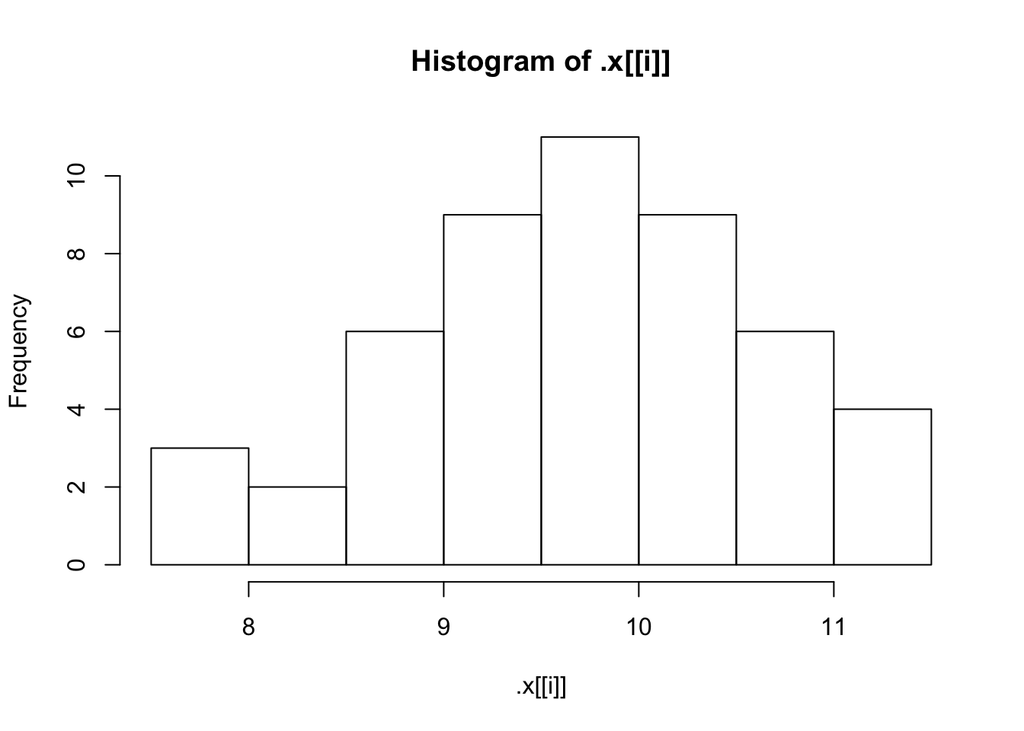

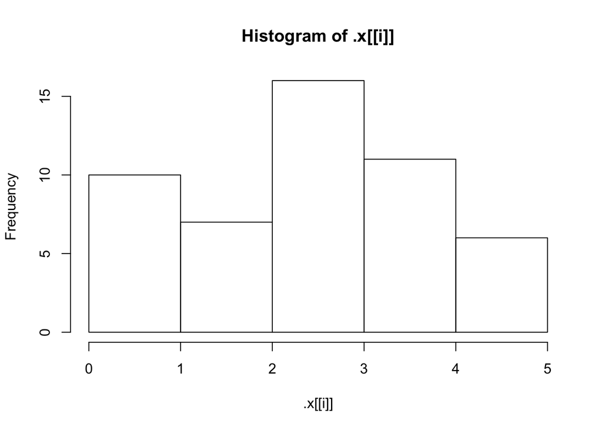

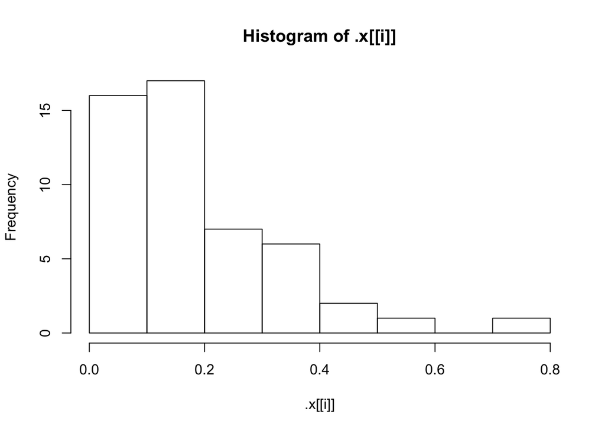

```r
# Define list of functions
f <- list(Normal = "rnorm", Uniform = "runif", Exp = "rexp")

# Define params
params <- list(
  Normal = list(mean = 10),
  Uniform = list(min = 0, max = 5),
  Exp = list(rate = 5)
)

# Assign the simulated samples to sims
sims <- invoke_map(f, params, n = 50)

# Use walk() to make a histogram of each element in sims
walk(sims, hist)
```

## Walking over two or more arguments

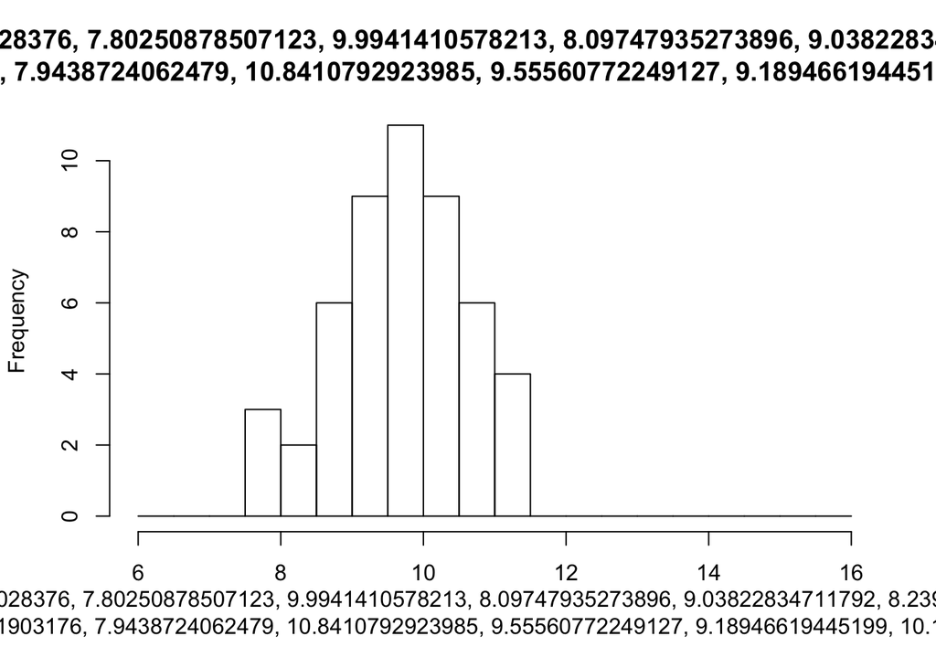

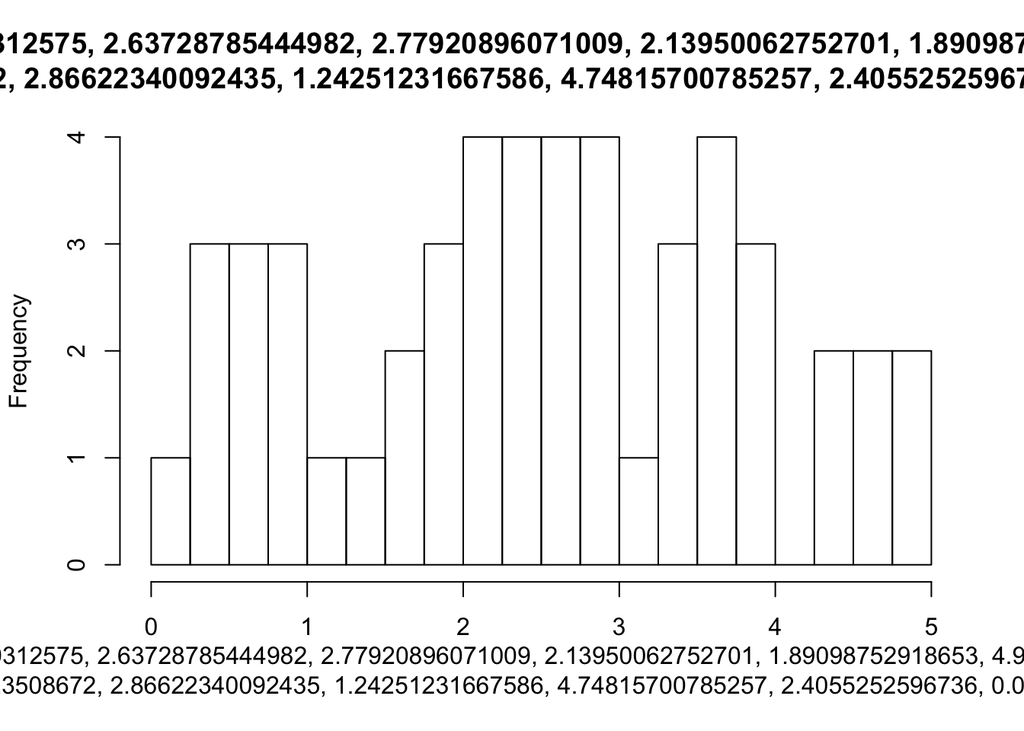

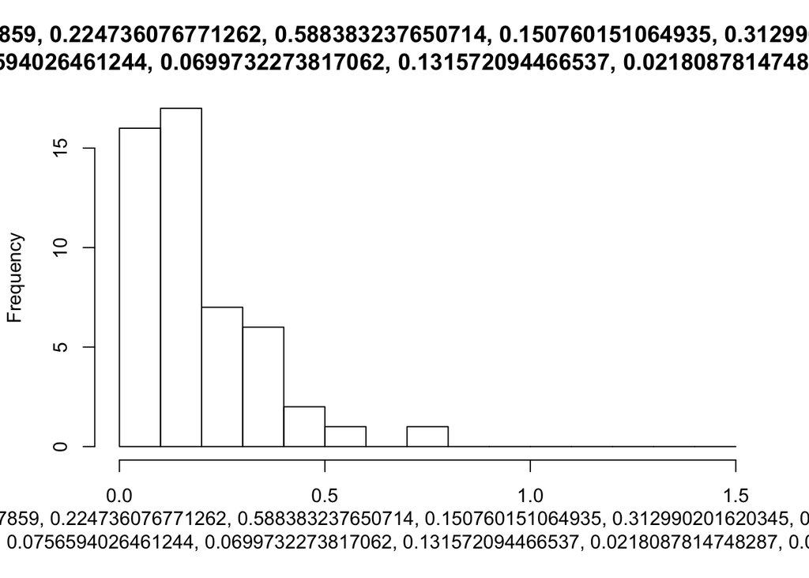

```r
# Replace "Sturges" with reasonable breaks for each sample
breaks_list <- list(
  Normal = seq(6, 16, 0.5),
  Uniform = seq(0, 5, 0.25),
  Exp = seq(0, 1.5, 0.1)
)

# Use walk2() to make histograms with the right breaks
walk2(sims, breaks_list, hist)
```

## Putting together writing functions and walk

```r
# Turn this snippet into find_breaks()

find_breaks <- function(x) {
  rng <- range(x, na.rm = TRUE)
  seq(rng[1], rng[2], length.out = 30)
}


# Call find_breaks() on sims[[1]]
find_breaks(sims[[1]])
```

```
##  [1]  7.613127  7.746538  7.879950  8.013362  8.146773  8.280185  8.413597
##  [8]  8.547008  8.680420  8.813832  8.947243  9.080655  9.214067  9.347478
## [15]  9.480890  9.614301  9.747713  9.881125 10.014536 10.147948 10.281360
## [22] 10.414771 10.548183 10.681595 10.815006 10.948418 11.081830 11.215241
## [29] 11.348653 11.482065
```

## Nice breaks for all

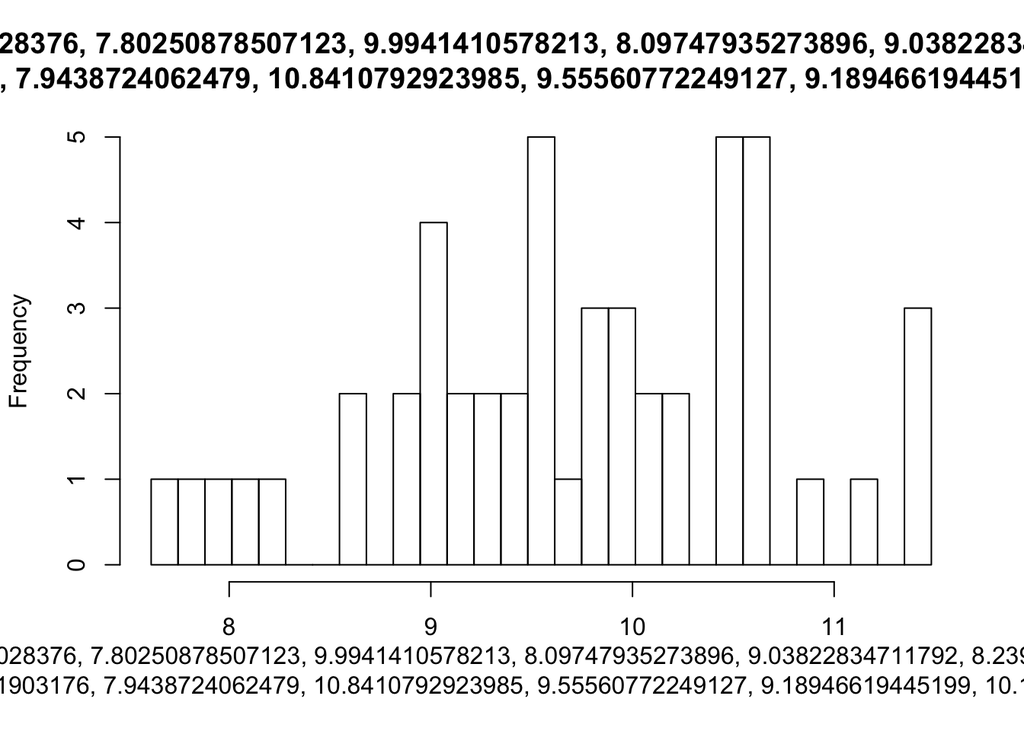

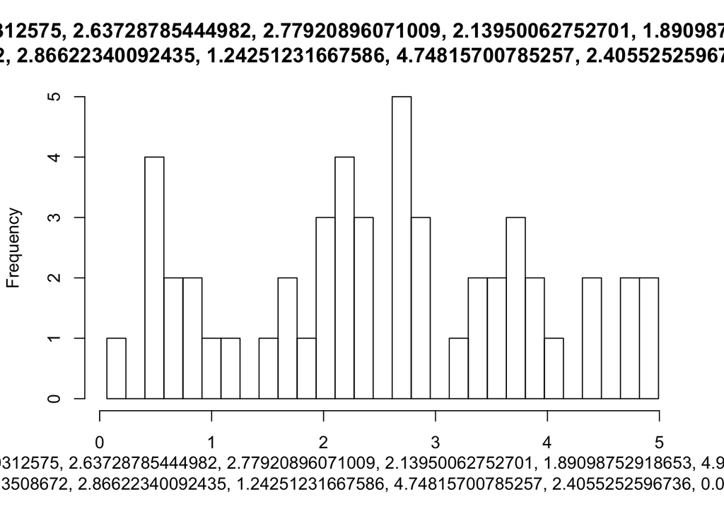

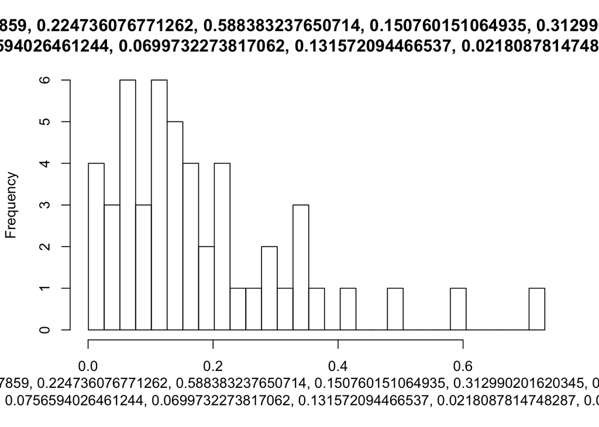

```r
# Use map() to iterate find_breaks() over sims: nice_breaks
nice_breaks <- map(sims, find_breaks)

# Use nice_breaks as the second argument to walk2()
walk2(sims, nice_breaks, hist)
```

## Walking with many argumnets: pwalk

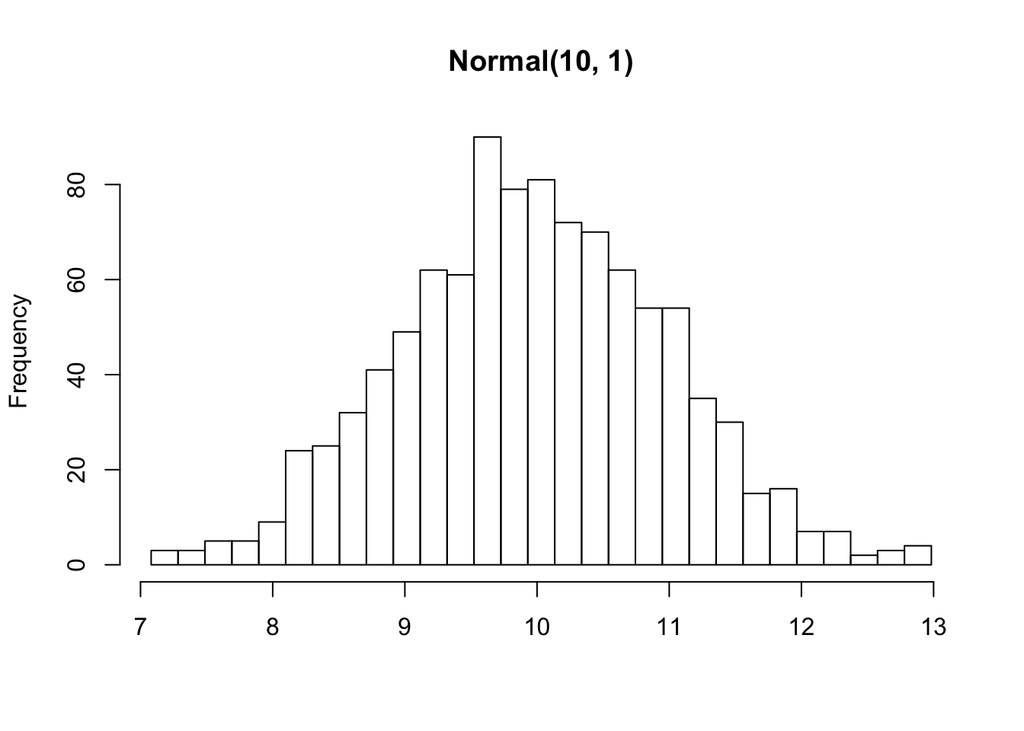

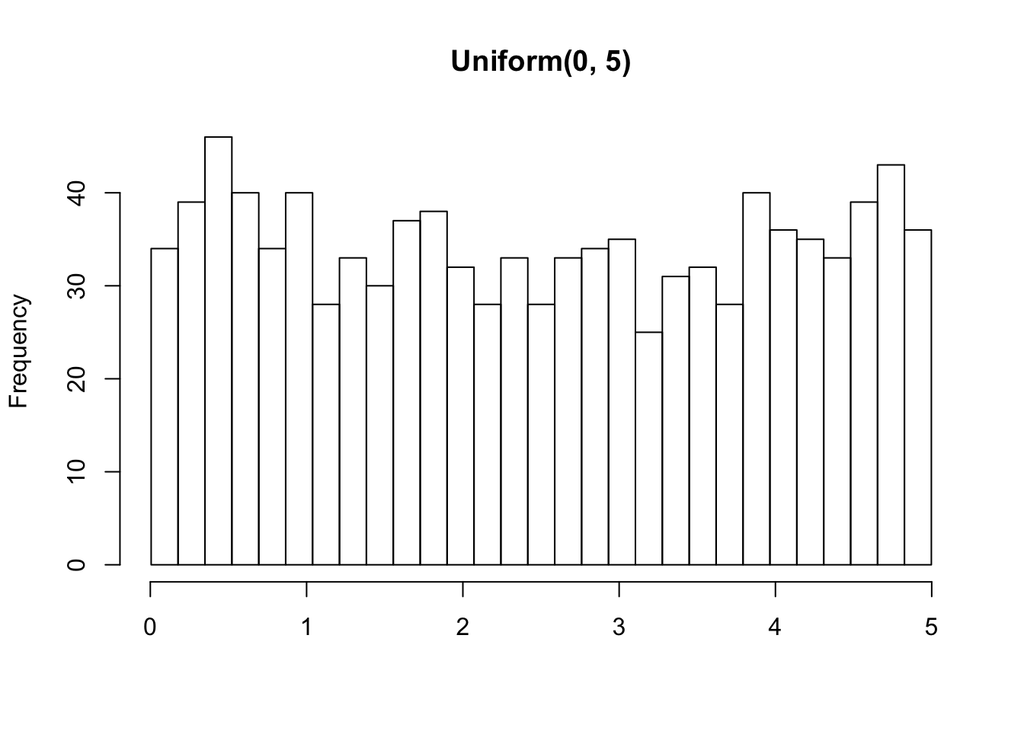

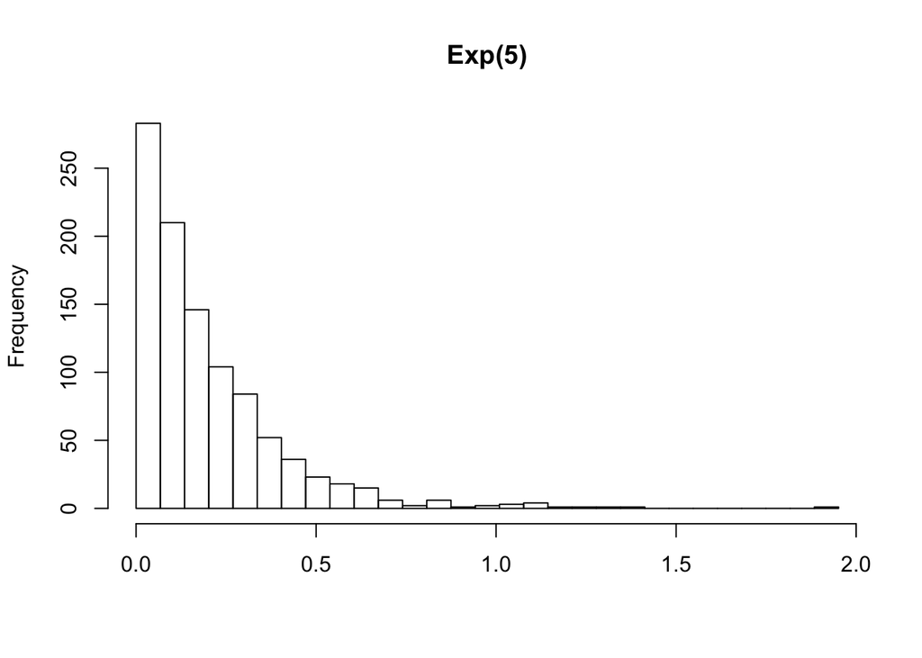

```r
# Increase sample size to 1000
sims <- invoke_map(f, params, n = 1000)

# Compute nice_breaks (don't change this)
nice_breaks <- map(sims, find_breaks)

# Create a vector nice_titles
nice_titles <- c(
  "Normal(10, 1)",
  "Uniform(0, 5)",
  "Exp(5)"
  )

# Use pwalk() instead of walk2()
pwalk(list(x = sims, breaks = nice_breaks, main = nice_titles), hist, xlab = "")
```

## Walking with pipes

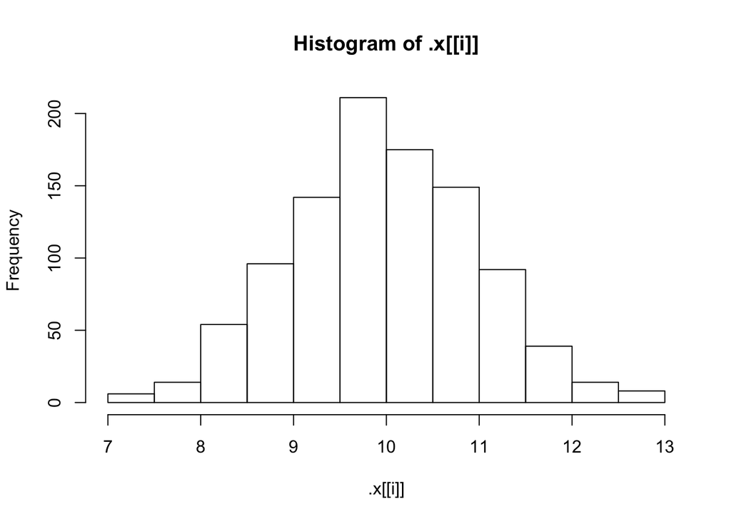

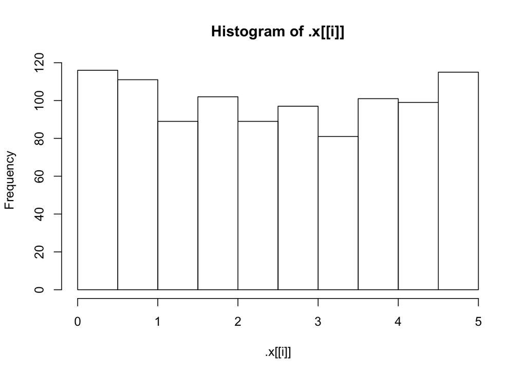

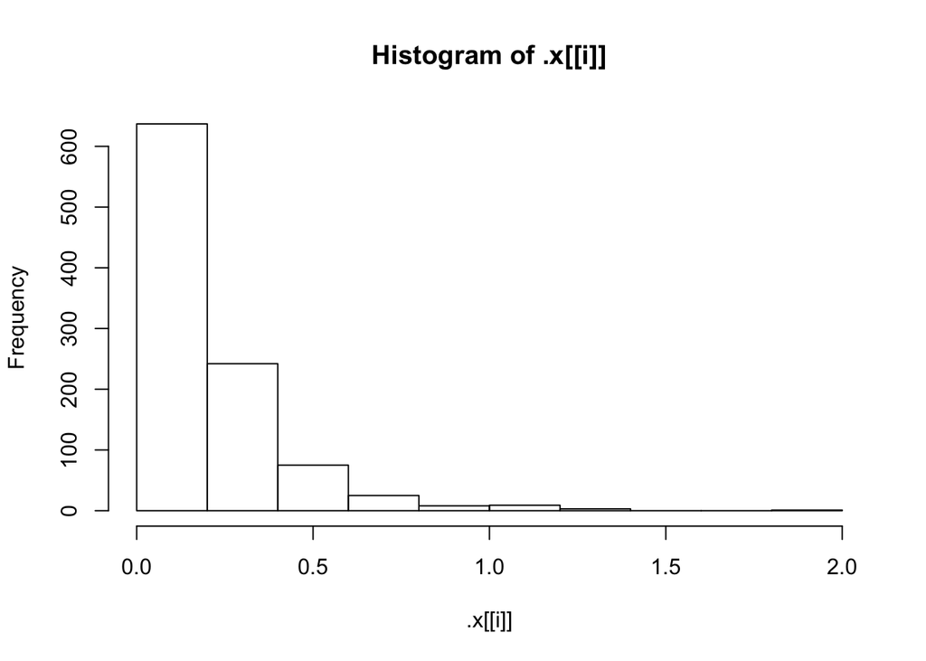

```
## $Normal
##    Min. 1st Qu.  Median    Mean 3rd Qu.    Max.
##   7.081   9.293   9.951   9.973  10.649  12.983
##
## $Uniform
##    Min. 1st Qu.  Median    Mean 3rd Qu.    Max.
## 0.00542 1.11491 2.45483 2.48446 3.85500 4.99769
##
## $Exp
##      Min.   1st Qu.    Median      Mean   3rd Qu.      Max.
## 0.0000448 0.0556245 0.1380562 0.1970419 0.2721849 1.9512666
```

```r
# Pipe this along to map(), using summary() as .f
sims %>%
  walk(hist) %>%
  map(summary)
```

# Robust functions

## Robust functions

- The outputs to these change based on the input
  - `df[, vars]`
  - `subset(df, x == y)`
  - `data.frame(x = "a")`
- The aim at interactive analysis which is helpful
  - But in programming you want strict outputs
- Three main problems
  - Type-unstable functions
  - Non-standard evaluations
  - Hidden arguments
- Throwing clear errors is important

## An error is better than a surprise

- This will give an error rather then weird results like we saw before

```r
# Define troublesome x and y
x <- c(NA, NA, NA)
y <- c( 1, NA, NA, NA)

both_na <- function(x, y) {
  # Add stopifnot() to check length of x and y
  stopifnot(length(x) == length(y))

  sum(is.na(x) & is.na(y))
}

# Call both_na() on x and y
both_na(x, y)
```

```
## Error: length(x) == length(y) is not TRUE
```

## An informative error is even better

- The error message should tell the uses what is needed

```r
# Define troublesome x and y
x <- c(NA, NA, NA)
y <- c( 1, NA, NA, NA)

both_na <- function(x, y) {
  # Replace condition with logical
  if (length(x) != length(y)) {
    # Replace "Error" with better message
    stop("x and y must have the same length", call. = FALSE)
  }

  sum(is.na(x) & is.na(y))
}

# Call both_na()
both_na(x, y)
```

```
## Error: x and y must have the same length
```

## unstable types

- Type-inconsistent: the type of the return object depends on the input
- Surprises occur when you’ve used a type-inconsistent functio inside your own function
- `[` is a common source of surprises
  - use `drop = FALSE`: `df[x, , drop = FALSE]`
  - Subset the data frame like a list: df[x]
- sapply is another type unstable function
- Avoid these when writting your functions and use type consistent functions instead or use tests to ensure type

## sapply is another common culprite

```r
df <- data.frame(
  a = 1L,
  b = 1.5,
  y = Sys.time(),
  z = ordered(1)
)

A <- sapply(df[1:4], class)
A
```

```
## $a
## [1] "integer"
##
## $b
## [1] "numeric"
##
## $y
## [1] "POSIXct" "POSIXt"
##
## $z
## [1] "ordered" "factor"
```

```r
B <- sapply(df[3:4], class)
B
```

```
##      y         z
## [1,] "POSIXct" "ordered"
## [2,] "POSIXt"  "factor"
```

## Using purrr solves the problem

```r
# sapply calls
A <- sapply(df[1:4], class)
B <- sapply(df[3:4], class)
C <- sapply(df[1:2], class)

# Demonstrate type inconsistency
str(A)
```

```
## List of 4
##  $ a: chr "integer"
##  $ b: chr "numeric"
##  $ y: chr [1:2] "POSIXct" "POSIXt"
##  $ z: chr [1:2] "ordered" "factor"
```

```r
str(B)
```

```
##  chr [1:2, 1:2] "POSIXct" "POSIXt" "ordered" "factor"
##  - attr(*, "dimnames")=List of 2
##   ..$ : NULL
##   ..$ : chr [1:2] "y" "z"
```

```r
str(C)
```

```
##  Named chr [1:2] "integer" "numeric"
##  - attr(*, "names")= chr [1:2] "a" "b"
```

```r
# Use map() to define X, Y and Z
X <- map(df[1:4], class)
Y <- map(df[3:4], class)
Z <- map(df[1:2], class)

# Use str() to check type consistency
str(X)
```

```
## List of 4
##  $ a: chr "integer"
##  $ b: chr "numeric"
##  $ y: chr [1:2] "POSIXct" "POSIXt"
##  $ z: chr [1:2] "ordered" "factor"
```

```r
str(Y)
```

```
## List of 2
##  $ y: chr [1:2] "POSIXct" "POSIXt"
##  $ z: chr [1:2] "ordered" "factor"
```

```r
str(Z)
```

```
## List of 2
##  $ a: chr "integer"
##  $ b: chr "numeric"
```

## A type consistent solution

```r
col_classes <- function(df) {
  # Assign list output to class_list
  class_list <- map(df, class)

  # Use map_chr() to extract first element in class_list
  map_chr(class_list, 1)

}

# Check that our new function is type consistent
df %>% col_classes() %>% str()
```

```
##  Named chr [1:4] "integer" "numeric" "POSIXct" "ordered"
##  - attr(*, "names")= chr [1:4] "a" "b" "y" "z"
```

```r
df[3:4] %>% col_classes() %>% str()
```

```
##  Named chr [1:2] "POSIXct" "ordered"
##  - attr(*, "names")= chr [1:2] "y" "z"
```

```r
df[1:2] %>% col_classes() %>% str()
```

```
##  Named chr [1:2] "integer" "numeric"
##  - attr(*, "names")= chr [1:2] "a" "b"
```

## Or fail early if something goes wrong

```r
## or make our own error message
col_classes <- function(df) {
  class_list <- map(df, class)

  # Add a check that no element of class_list has length > 1
  if (any(map_dbl(class_list, length) > 1)) {
    stop("Some columns have more than one class", call. = FALSE)
  }

  # Use flatten_chr() to return a character vector
  flatten_chr(class_list)
}

# Check that our new function is type consistent
df %>% col_classes() %>% str()
```

```
## Error: Some columns have more than one class
```

```r
df[3:4] %>% col_classes() %>% str()
```

```
## Error: Some columns have more than one class
```

```r
df[1:2] %>% col_classes() %>% str()
```

```
##  chr [1:2] "integer" "numeric"
```

## Non-standard evaluation

- NSE function don’t use the normal lookup roles
- Things like subsetting, dply filter, ggplot are examples
- What to do
  - Using NSE functions inside your own functions can cause surprises
  - Avoind using NSE functions inside your functions
  - Or learn the suprising cases and protect against them
  - I’ll probably choose the later, because using dplyr inside functions is something I do a lot
  - But I am usually working on a constrained dataset and problem, not writting packages for other people

## Programming with NSE functions

```r
big_x <- function(df, threshold) {
  dplyr::filter(df, x > threshold)
}

# Use big_x() to find rows in diamonds_sub where x > 7
big_x(diamonds_sub, 7)
```

```
## # A tibble: 2 x 10
##   carat   cut color clarity depth table price     x     y     z
##   <dbl> <ord> <ord>   <ord> <dbl> <dbl> <int> <dbl> <dbl> <dbl>
## 1  1.35 Ideal     G     VS1  60.9    54 10471  7.18  7.15  4.36
## 2  1.63 Ideal     F      I1  62.0    55  7229  7.57  7.50  4.68
```

## When things go wrong

```r
# Remove the x column from diamonds
diamonds_sub$x <- NULL

# Create variable x with value 1
x <- 1

# Use big_x() to find rows in diamonds_sub where x > 7
big_x(diamonds_sub, 7)
```

```
## # A tibble: 0 x 9
## # ... with 9 variables: carat <dbl>, cut <ord>, color <ord>,
## #   clarity <ord>, depth <dbl>, table <dbl>, price <int>, y <dbl>, z <dbl>
```

```r
# Create a threshold column with value 100
diamonds_sub$threshold <- 100

# Use big_x() to find rows in diamonds_sub where x > 7
big_x(diamonds_sub, 7)
```

```
## # A tibble: 0 x 10
## # ... with 10 variables: carat <dbl>, cut <ord>, color <ord>,
## #   clarity <ord>, depth <dbl>, table <dbl>, price <int>, y <dbl>,
## #   z <dbl>, threshold <dbl>
```

## What to do?

```r
big_x <- function(df, threshold) {
  # Write a check for x not being in df
  if (!'x' %in% names(df)) {
    stop("df must contain variable called x", call. = FALSE)
  }

  # Write a check for threshold being in df
  if ('threshold' %in% names(df)) {
    stop("df must not contain variable called threshold", call. = FALSE)
  }

  dplyr::filter(df, x > threshold)
}

big_x(diamonds_sub, 7)
```

```
## Error: df must contain variable called x
```

## Hidden arguments

- Pure functions
  - Their output only depends on their inputs
  - They don’t affect the outside workd except through their return value
- Hidden arguments are function inputs taht may be different for different users or sessions
  - Common example: argument defaults taht depend on global options
- The return value of a function shouild **never** depend on a global option
  - Side effects may be controlled by global options

## A hidden dependence

```r
# Read in the swimming_pools.csv to pools
url_csv <- "http://s3.amazonaws.com/assets.datacamp.com/production/course_1478/datasets/swimming_pools.csv"
swimming_pools <- read.csv(url_csv)

# Examine the structure of pools
str(pools)
```

```
## 'data.frame':    20 obs. of  4 variables:
##  $ Name     : Factor w/ 20 levels "Acacia Ridge Leisure Centre",..: 1 2 3 4 5 6 19 7 8 9 ...
##  $ Address  : Factor w/ 20 levels "1 Fairlead Crescent, Manly",..: 5 20 18 10 9 11 6 15 12 17 ...
##  $ Latitude : num  -27.6 -27.6 -27.6 -27.5 -27.4 ...
##  $ Longitude: num  153 153 153 153 153 ...
```

```r
# Change the global stringsAsFactor option to FALSE
options(stringsAsFactors = F)
getOption("stringsAsFactors")
```

```
## [1] FALSE
```

```r
# Read in the swimming_pools.csv to pools2
pools2 <- read.csv(url_csv)

# Examine the structure of pools2
str(pools2)
```

```
## 'data.frame':    20 obs. of  4 variables:
##  $ Name     : chr  "Acacia Ridge Leisure Centre" "Bellbowrie Pool" "Carole Park" "Centenary Pool (inner City)" ...
##  $ Address  : chr  "1391 Beaudesert Road, Acacia Ridge" "Sugarwood Street, Bellbowrie" "Cnr Boundary Road and Waterford Road Wacol" "400 Gregory Terrace, Spring Hill" ...
##  $ Latitude : num  -27.6 -27.6 -27.6 -27.5 -27.4 ...
##  $ Longitude: num  153 153 153 153 153 ...
```

## Legitimate use of options

```r
# Fit a regression model
fit <- lm(mpg ~ wt, data = mtcars)

# Look at the summary of the model
summary(fit)
```

```
##
## Call:
## lm(formula = mpg ~ wt, data = mtcars)
##
## Residuals:
##     Min      1Q  Median      3Q     Max
## -4.5432 -2.3647 -0.1252  1.4096  6.8727
##
## Coefficients:
##             Estimate Std. Error t value Pr(>|t|)
## (Intercept)  37.2851     1.8776  19.858  < 2e-16 ***
## wt           -5.3445     0.5591  -9.559 1.29e-10 ***
## ---
## Signif. codes:  0 '***' 0.001 '**' 0.01 '*' 0.05 '.' 0.1 ' ' 1
##
## Residual standard error: 3.046 on 30 degrees of freedom
## Multiple R-squared:  0.7528, Adjusted R-squared:  0.7446
## F-statistic: 91.38 on 1 and 30 DF,  p-value: 1.294e-10
```

```r
# Set the global digits option to 2
options(digits = 2)

# Take another look at the summary
summary(fit)
```

```
##
## Call:
## lm(formula = mpg ~ wt, data = mtcars)
##
## Residuals:
##    Min     1Q Median     3Q    Max
## -4.543 -2.365 -0.125  1.410  6.873
##
## Coefficients:
##             Estimate Std. Error t value Pr(>|t|)
## (Intercept)   37.285      1.878   19.86  < 2e-16 ***
## wt            -5.344      0.559   -9.56  1.3e-10 ***
## ---
## Signif. codes:  0 '***' 0.001 '**' 0.01 '*' 0.05 '.' 0.1 ' ' 1
##
## Residual standard error: 3 on 30 degrees of freedom
## Multiple R-squared:  0.753,  Adjusted R-squared:  0.745
## F-statistic: 91.4 on 1 and 30 DF,  p-value: 1.29e-10
```